# Assignment1

Hang_YU

December 24, 2017

```r
knitr::opts_chunk$set(echo = TRUE, error = FALSE, warning = FALSE, message = FALSE)
```

## Introduction

In this assignment, the activity data set is explorerd and analyzed.

## Data loading and preprocessing

The csv file is loaded along with the formatting of time variables.

```r
activity <- read.csv("activity.csv",head=TRUE)
activity$date <- as.Date(activity$date,format="%Y-%m-%d")
head(activity,5)
```

```
##   steps       date interval
## 1    NA 2012-10-01        0
## 2    NA 2012-10-01        5
## 3    NA 2012-10-01       10
## 4    NA 2012-10-01       15
## 5    NA 2012-10-01       20
```

```r
str(activity)
```

```
## 'data.frame':    17568 obs. of  3 variables:
##  $ steps   : int  NA NA NA NA NA NA NA NA NA NA ...
##  $ date    : Date, format: "2012-10-01" "2012-10-01" ...
##  $ interval: int  0 5 10 15 20 25 30 35 40 45 ...
```

## Mean total number of steps taken per day

### Aggregate the total number of steps per day

To obtain the daily total steps, the step data is aggregated for each day.

The new data set is stored in activity-daily.

```r
library(dplyr)
activity_daily <- aggregate(steps~date,activity,sum,na.rm=TRUE)
```

### Histogram of total number of steps per day

Now the histogram of total number of steps per day is plotted.

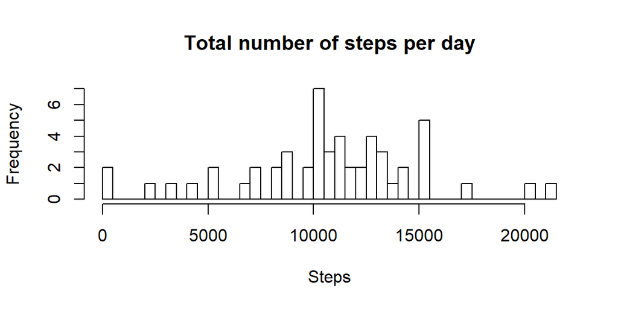

```r
hist(activity_daily$steps,breaks = 50, main = "Total number of steps per day", xlab = "Steps")
```

### Mean and median of total number of steps per day

The mean and median of the total number of steps per day are calculated as below:

```r
mean(activity_daily$steps)
```

```
## [1] 10766.19
```

```r
median(activity_daily$steps)
```

```
## [1] 10765
```

## average daily activity pattern

Now we investigate the daily activity pattern.

To do this we first aggregate the number of steps for each 5 min over all days.

```r
activity_5min <- aggregate(steps~interval,activity,sum,na.rm=TRUE)
```

### Time series plot

Here is a time series plot presenting the number of steps for each 5 min over all days.

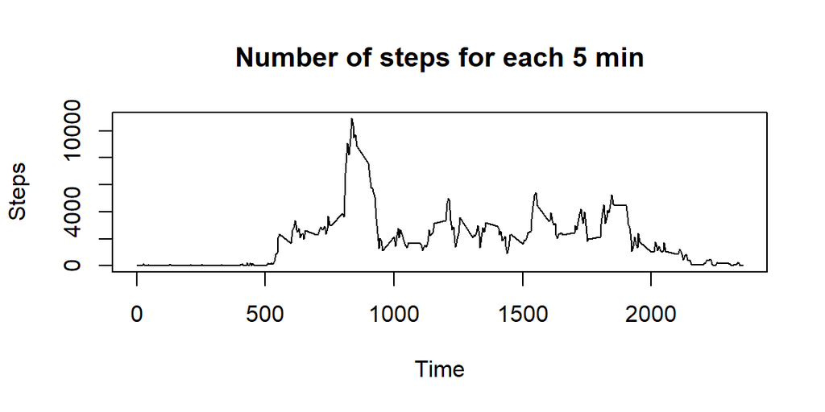

```r
plot(activity_5min$interval,activity_5min$steps,type="l",main="Number of steps for each 5 min", xlab="Time", ylab="Steps")
```

### The interval with the maximum number of steps

The interval that has the maximal number of steps on average is calculated as below:

```r
activity_5min %>% subset(steps == max(steps))
```

```
##     interval steps
## 104      835 10927
```

So the interval 835 has the maximal average number of steps.

## Imputing missing values

### Number of missing values

```r
nrow(activity %>% filter(is.na(steps)))
```

```
## [1] 2304
```

### Median Imputation

The imputation technique adopted here is the median imputation for each interval.

```r
steps_median <- activity %>% aggregate(steps~interval,data=.,median,na.rm=TRUE)
activity$steps_impute <- ifelse(is.na(activity$steps),steps_median[which(activity$interval==steps_median$interval),"steps"],activity$steps)
```

### Histogram of total number of steps per day

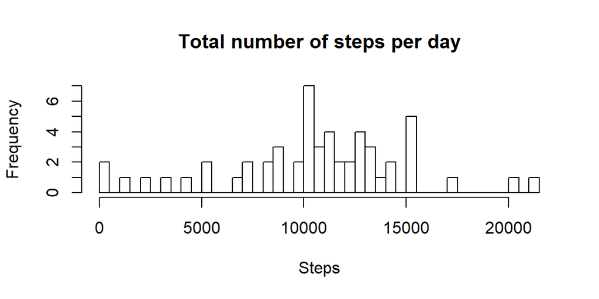

```r
activity_daily_impute <- aggregate(steps_impute~date,activity,sum,na.rm=TRUE)
hist(activity_daily_impute$steps_impute,breaks=50,main = "Total number of steps per day", xlab = "Steps")
```

### Mean and median of total number of steps per day

The mean and median of the total number of steps per day after imputation are calculated as below:

```r
mean(activity_daily_impute$steps_impute)
```

```
## [1] 10587.94
```

```r
median(activity_daily_impute$steps_impute)
```

```
## [1] 10682.5
```

In comparison with the values before imputation, the imputed mean and median go down because of the imputed values regressing to the median.

### Difference between weekdays and weekends

Determine weekdays and weekends of the imputed data set

```r
activity <- activity %>% mutate(date_wk=weekdays(date))
activity$date_wk <- ifelse(activity$date_wk %in% c("Sunday","Saturday"),"Weekend","Weekday")
activity$date_wk <- as.factor(activity$date_wk)
```

Plot the corresponding time series using lattice plot.

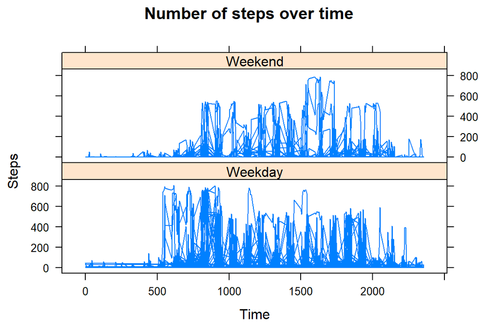

```r
library(lattice)
xyplot(steps_impute ~ interval|date_wk, data=activity, type='l',layout=c(1,2),ylab="Steps", xlab="Time", main="Number of steps over time")
```

It can be observed that people start to walk earlier on weekdays than weekends.